## VerticaPy

### *Python API for Vertica Data Science at Scale*

# Identificação de níveis de suporte e resistência nos preços das ações do indice IBOVESPA usando Machine Learning e Vertica

Os algoritmos de Machine Learning permitem analisar os dados e descobrir relacionamentos e padrões dentro deles usando técnicas de classificação. VerticaPy é a nova biblioteca de Python para conduzir projetos de ciência de dados usando os dados armazenados dentro do banco de dados Vertica e aproveitando sua velocidade, processamento massivamente paralelo, armazenamento em colunas, compactação avançada e projeções otimizadas, assim como as características de análise e Machine Learning incluídos no banco.

Por outro lado, os níveis de suporte e resistência nos preços das ações são definidos como certos níveis de preço nos quais o preço pode parar e reverter devido a um número maior de investidores interessados nesses níveis de preço. Os níveis de suporte e resistência são importantes porque indicam pontos de inflexão do mercado, onde é provável que o mercado altere a direção do movimento. Portanto, identificando as linhas de suporte e resistência e suporte, você pode escolher os melhores momentos para comprar a um preço baixo (quando o preço se aproximar do suporte) ou vender por um preço mais alto (quando o preço se aproximar da resistência).

Para resolver o problema de identificar níveis relevantes de suporte e resistência nos preços das ações usaremos o método de agrupamento K-means disponível na biblioteca de algoritmos de classificação não supervisionados do Vertica para particionar as observações em K agrupamentos onde cada observação pertence ao agrupamento com a média mais próxima do centroide.

Seguiremos o pipeline do cientista de dados com as seguintes fases: Exploração de Dados, Preparação de Dados, Criação do Modelo de Aprendizado e Avaliação do Modelo.

Os datasets a serem usados dos preços das principais ações do índice IBOVEPSA, tem os seguintes atributos:

- **date:** Data do pregão da negociação
- **open:** Preço de abertura da ação
- **low:** Preço mínimo da ação no pregão
- **high:** Preço máximo da ação no pregão
- **close:** Preço de fechamento da ação

## 1. Exploração de Dados

Na fase de exploração de dados iremos:

- Criar os dataframes com os dados dos preços das ações selecionadas do índice IBOVESPA
- Calcular as agregações estatísticas dos dados de cada ação
- Plotar os dados de cada ação selecionada

```python
import verticapy as vp
vp.new_connection({"host": "3.20.216.192", "port": "5433", "database": "imexdb", "password": "imex2022@!", "user": "dbadmin"}, name="DSN_IMEXDB")
```

#### Criar os virtual Dataframes com os dados dos preços das principais ações do indice Bovespa

```python
from verticapy.utilities import *
from verticapy import *

set_option("max_rows", 4)
set_option("tqdm",False)
vp.connect("DSN_IMEXDB")

a_vdf_stocks = []
a_vdf_stocks.append(vDataFrameSQL("(select 'IBOV' stock, timestampData date, open, low, high, close from STOCK.STOCKQUOTES where symbol like '^BVSP') x"))
a_vdf_stocks.append(vDataFrameSQL("(select 'VALE3' stock, timestampData date, open, low, high, close from STOCK.STOCKQUOTES where symbol like 'VALE3.SA') x"))
a_vdf_stocks.append(vDataFrameSQL("(select 'PETR3' stock, timestampData date, open, low, high, close from STOCK.STOCKQUOTES where symbol like 'PETR3.SA') x"))
a_vdf_stocks.append(vDataFrameSQL("(select 'BBAS3' stock, timestampData date, open, low, high, close from STOCK.STOCKQUOTES where symbol like 'BBAS3.SA') x"))
a_vdf_stocks.append(vDataFrameSQL("(select 'BBDC4' stock, timestampData date, open, low, high, close from STOCK.STOCKQUOTES where symbol like 'BBDC4.SA') x"))
a_vdf_stocks.append(vDataFrameSQL("(select 'ITUB4' stock, timestampData date, open, low, high, close from STOCK.STOCKQUOTES where symbol like 'ITUB4.SA') x"))

a_stock_symbols = []
for vdf_stock in a_vdf_stocks:
    a_stock_symbols.append(vdf_stock['stock'][0])
    display(vdf_stock.sort({'date':'desc'}))
```

Abc

**stock**

Varchar(4)

📅

**date**

Datetime

123

**open**

Float

123

**low**

Float

123

**high**

Float

123

**close**

Float

**1**

IBOV

2022-07-29 13:00:00

102597.0

102514.0

103989.0

103165.0

**2**

IBOV

2022-07-28 13:00:00

101437.0

101045.0

102686.0

102597.0

**3**

IBOV

2022-07-27 13:00:00

99773.0

99772.0

101471.0

101438.0

**4**

IBOV

2022-07-26 13:00:00

100270.0

99365.0

100753.0

99772.0

**Rows:** 1-4 | **Columns:** 6

Abc

**stock**

Varchar(5)

📅

**date**

Datetime

123

**open**

Float

123

**low**

Float

123

**high**

Float

123

**close**

Float

**1**

VALE3

2022-07-29 13:00:00

69.67

68.03

70.32

69.75

**2**

VALE3

2022-07-28 13:00:00

71.46

70.31

71.97

70.69

**3**

VALE3

2022-07-27 13:00:00

69.97

69.31

70.62

70.52

**4**

VALE3

2022-07-26 13:00:00

71.32

69.58

71.42

70.36

**Rows:** 1-4 | **Columns:** 6

Abc

**stock**

Varchar(5)

📅

**date**

Datetime

123

**open**

Float

123

**low**

Float

123

**high**

Float

123

**close**

Float

**1**

PETR3

2022-07-29 13:00:00

36.07

35.45

37.38

36.96

**2**

PETR3

2022-07-28 13:00:00

34.22

33.92

35.14

34.73

**3**

PETR3

2022-07-27 13:00:00

34.0

33.2

34.07

34.01

**4**

PETR3

2022-07-26 13:00:00

33.48

33.37

34.21

33.79

**Rows:** 1-4 | **Columns:** 6

Abc

**stock**

Varchar(5)

📅

**date**

Datetime

123

**open**

Float

123

**low**

Float

123

**high**

Float

123

**close**

Float

**1**

BBAS3

2022-07-29 13:00:00

36.17

35.9

36.59

35.97

**2**

BBAS3

2022-07-28 13:00:00

35.65

35.44

36.32

36.21

**3**

BBAS3

2022-07-27 13:00:00

35.41

35.13

35.64

35.55

**4**

BBAS3

2022-07-26 13:00:00

35.36

35.13

35.79

35.32

**Rows:** 1-4 | **Columns:** 6

Abc

**stock**

Varchar(5)

📅

**date**

Datetime

123

**open**

Float

123

**low**

Float

123

**high**

Float

123

**close**

Float

**1**

BBDC4

2022-07-29 13:00:00

17.39

17.32

17.72

17.43

**2**

BBDC4

2022-07-28 13:00:00

17.2

16.96

17.41

17.39

**3**

BBDC4

2022-07-27 13:00:00

17.22

17.07

17.33

17.26

**4**

BBDC4

2022-07-26 13:00:00

17.27

17.02

17.46

17.16

**Rows:** 1-4 | **Columns:** 6

Abc

**stock**

Varchar(5)

📅

**date**

Datetime

123

**open**

Float

123

**low**

Float

123

**high**

Float

123

**close**

Float

**1**

ITUB4

2022-07-29 13:00:00

23.74

23.47

23.98

23.62

**2**

ITUB4

2022-07-28 13:00:00

23.55

23.29

23.73

23.7

**3**

ITUB4

2022-07-27 13:00:00

23.62

23.4

23.8

23.55

**4**

ITUB4

2022-07-26 13:00:00

23.63

23.32

23.9

23.47

**Rows:** 1-4 | **Columns:** 6

#### Calcular as agregações estatísticas dos dados de cada Dataframe

```python
for vdf_stock in a_vdf_stocks:
    display(vdf_stock.describe(method = "all"))
```

123

**"open"**

Float

100%

123

**"low"**

Float

100%

123

**"high"**

Float

100%

123

**"close"**

Float

100%

📅

**"date"**

Datetime

100%

Abc

**"stock"**

Varchar(4)

100%

**dtype**

float

float

float

float

datetime

varchar(4)

**percent**

100.0

100.0

100.0

100.0

100.0

100.0

**count**

7240

7240

7240

7240

7240

7240

**top**

65178.0

23.7

11296.0

49246.0

1994-06-15 13:00:00

IBOV

**top_percent**

0.041

0.041

0.055

0.041

0.014

100.0

**avg**

43556.6711740884

43096.3719887293

44010.8359395304

43565.3816849862

[null]

4.0

**stddev**

33204.8041539803

32918.0770968922

33492.668673469

33212.3860745537

[null]

0.0

**min**

23.7

23.7

24.2

23.7

1993-04-27 13:00:00

4

**approx_25%**

12204.28

11973.7727272727

12354.6470588235

12174.5945945946

[null]

4

**approx_50%**

44941.4545454546

44303.0833333333

45509.7272727273

45077.3333333333

[null]

4

**approx_75%**

63863.0

62993.1904761905

64436.25

63771.4545454545

[null]

4

**max**

130776.0

129526.0

131190.0

130776.0

2022-07-29 13:00:00

4

**range**

130752.3

129502.3

131165.8

130752.3

b'10685'

0

**empty**

[null]

[null]

[null]

[null]

[null]

0

**Rows:** 1-14 | **Columns:** 7

123

**"open"**

Float

100%

123

**"low"**

Float

100%

123

**"high"**

Float

100%

123

**"close"**

Float

100%

📅

**"date"**

Datetime

100%

Abc

**"stock"**

Varchar(5)

100%

**dtype**

float

float

float

float

datetime

varchar(5)

**percent**

100.0

100.0

100.0

100.0

100.0

100.0

**count**

5673

5673

5673

5673

5673

5673

**top**

4.0

3.9167

4.4167

4.0

2008-05-08 13:00:00

VALE3

**top_percent**

0.388

0.335

0.335

0.353

0.018

100.0

**avg**

34.5898925436277

34.0698307244844

35.0681858628592

34.5646017627358

[null]

5.0

**stddev**

23.5850788212064

23.2541386562284

23.8527942574274

23.5517003799509

[null]

0.0

**min**

2.875

2.75

2.9217

2.8333

2000-01-03 12:00:00

5

**approx_25%**

16.379

16.175

16.73

16.50375

[null]

5

**approx_50%**

32.2508333333333

31.83

32.792

32.2491666666667

[null]

5

**approx_75%**

48.6733333333333

48.0466666666667

49.2266666666667

48.67

[null]

5

**max**

119.8

115.25

120.45

118.72

2022-07-29 13:00:00

5

**range**

116.925

112.5

117.5283

115.8867

b'8243 01:00'

0

**empty**

[null]

[null]

[null]

[null]

[null]

0

**Rows:** 1-14 | **Columns:** 7

123

**"open"**

Float

100%

123

**"low"**

Float

100%

123

**"high"**

Float

100%

123

**"close"**

Float

100%

📅

**"date"**

Datetime

100%

Abc

**"stock"**

Varchar(5)

100%

**dtype**

float

float

float

float

datetime

varchar(5)

**percent**

100.0

100.0

100.0

100.0

100.0

100.0

**count**

5598

5598

5598

5598

5598

5598

**top**

6.625

6.625

6.625

6.625

2008-05-08 13:00:00

PETR3

**top_percent**

0.232

0.232

0.232

0.232

0.018

100.0

**avg**

20.7925558235084

20.4768832618792

21.087759467667

20.7742162379421

[null]

5.0

**stddev**

11.1433261319036

10.9269268567372

11.3363391565824

11.1309098509686

[null]

5.96046447753906e-08

**min**

3.9141

3.9141

3.9141

3.9141

2000-01-03 12:00:00

5

**approx_25%**

11.6901333333333

11.5573916666667

11.72762125

11.6425

[null]

5

**approx_50%**

19.7877777777778

19.472

20.1206547619048

19.7985714285714

[null]

5

**approx_75%**

28.5175

28.114

28.9666666666667

28.50625

[null]

5

**max**

62.53

61.83

63.9

62.3

2022-07-29 13:00:00

5

**range**

58.6159

57.9159

59.9859

58.3859

b'8243 01:00'

0

**empty**

[null]

[null]

[null]

[null]

[null]

0

**Rows:** 1-14 | **Columns:** 7

123

**"open"**

Float

100%

123

**"low"**

Float

100%

123

**"high"**

Float

100%

123

**"close"**

Float

100%

📅

**"date"**

Datetime

100%

Abc

**"stock"**

Varchar(5)

100%

**dtype**

float

float

float

float

datetime

varchar(5)

**percent**

100.0

100.0

100.0

100.0

100.0

100.0

**count**

5582

5582

5582

5582

5582

5582

**top**

29.0

2.0667

2.0

30.0

2008-05-08 13:00:00

BBAS3

**top_percent**

0.358

0.251

0.251

0.287

0.018

100.0

**avg**

22.1773005732712

21.8166044607668

22.5229476531709

22.1669643496954

[null]

5.0

**stddev**

12.4346448076899

12.2679410486402

12.5835545135453

12.4261487900692

[null]

5.96046447753906e-08

**min**

1.8333

1.77

1.8833

1.8333

2000-01-03 12:00:00

5

**approx_25%**

11.96

11.7075

12.24165

11.99835

[null]

5

**approx_50%**

23.903125

23.4705882352941

24.2731818181818

23.885

[null]

5

**approx_75%**

29.98

29.57

30.45

30.0005882352941

[null]

5

**max**

55.6

54.82

55.91

55.18

2022-07-29 13:00:00

5

**range**

53.7667

53.05

54.0267

53.3467

b'8243 01:00'

0

**empty**

[null]

[null]

[null]

[null]

[null]

0

**Rows:** 1-14 | **Columns:** 7

123

**"open"**

Float

100%

123

**"low"**

Float

100%

123

**"high"**

Float

100%

123

**"close"**

Float

100%

📅

**"date"**

Datetime

100%

Abc

**"stock"**

Varchar(5)

100%

**dtype**

float

float

float

float

datetime

varchar(5)

**percent**

100.0

100.0

100.0

100.0

100.0

100.0

**count**

3617

3617

3617

3617

3617

3617

**top**

11.0016

11.0016

11.0016

11.0016

2020-05-27 13:00:00

BBDC4

**top_percent**

2.626

2.654

2.654

2.654

0.028

100.0

**avg**

15.9734504285319

15.7440979264584

16.1862862040365

15.96924069671

[null]

5.0

**stddev**

4.95795053113445

4.88179016619831

5.01610780576315

4.95094654170482

[null]

0.0

**min**

8.0061

7.9638

8.1472

8.0014

2008-01-02 12:00:00

5

**approx_25%**

11.568725

11.43904

11.7069117647059

11.5655111111111

[null]

5

**approx_50%**

14.65215

14.3678666666667

14.8751333333333

14.6734

[null]

5

**approx_75%**

19.4033

19.1364

19.6455

19.3636

[null]

5

**max**

29.7521

29.3163

30.0075

29.6093

2022-07-29 13:00:00

5

**range**

21.746

21.3525

21.8603

21.6079

b'5322 01:00'

0

**empty**

[null]

[null]

[null]

[null]

[null]

0

**Rows:** 1-14 | **Columns:** 7

123

**"open"**

Float

100%

123

**"low"**

Float

100%

123

**"high"**

Float

100%

123

**"close"**

Float

100%

📅

**"date"**

Datetime

100%

Abc

**"stock"**

Varchar(5)

100%

**dtype**

float

float

float

float

datetime

varchar(5)

**percent**

100.0

100.0

100.0

100.0

100.0

100.0

**count**

5420

5420

5420

5420

5420

5420

**top**

2.9307

3.0632

3.146

14.2398

2008-05-08 13:00:00

ITUB4

**top_percent**

0.24

0.221

0.24

0.203

0.018

100.0

**avg**

16.3054072509225

16.0793076568266

16.5213914575646

16.3015873062731

[null]

5.0

**stddev**

9.36110828092041

9.24573589924046

9.46820161654101

9.35388736491503

[null]

0.0

**min**

1.8876

1.8217

1.9373

1.9207

2000-12-21 12:00:00

5

**approx_25%**

9.8726625

9.58495

10.08615

9.85668571428571

[null]

5

**approx_50%**

15.7017583333333

15.4588166666667

15.88154

15.6653777777778

[null]

5

**approx_75%**

22.6995285714286

22.406

23.0630733333333

22.75036

[null]

5

**max**

38.67

38.4

39.79

39.69

2022-07-29 13:00:00

5

**range**

36.7824

36.5783

37.8527

37.7693

b'7890 01:00'

0

**empty**

[null]

[null]

[null]

[null]

[null]

0

**Rows:** 1-14 | **Columns:** 7

#### Plotar os dados de cada ação analisada

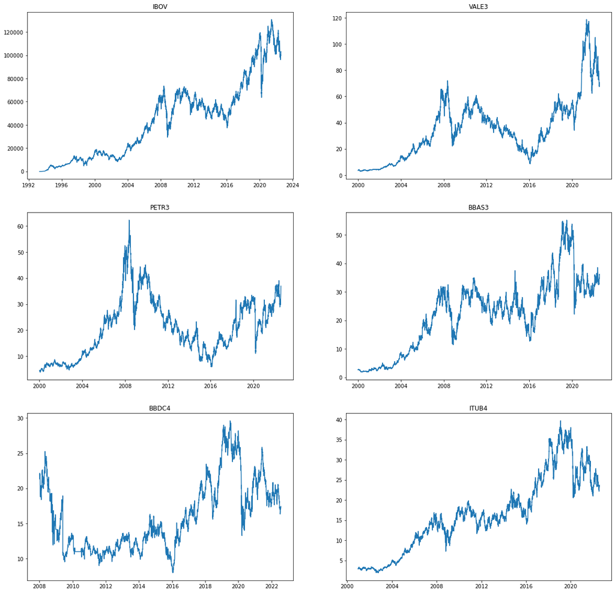

```python
from matplotlib import pyplot as plt
(nrows,ncols)=(3,2)
fig, axis = plt.subplots(nrows,ncols,figsize=(20, 20))

for i in range(nrows):
    for j in range(ncols):
        idx = i*ncols + j
        df_stock = a_vdf_stocks[idx].to_pandas()
        axis[i][j].title.set_text(a_stock_symbols[idx])
        axis[i][j].plot(df_stock['date'], df_stock['close'])
plt.figure()
plt.show()
```

## 2. Preparação de Dados

#### Calculo da matriz de correlação

**"IBOV"**

**"VALE3"**

**"PETR3"**

**"BBAS3"**

**"BBDC4"**

**"ITUB4"**

**"IBOV"**

1.0

0.830574864453601

0.299550394097662

0.753965704728239

0.742523124235476

0.78544525533136

**"VALE3"**

0.830574864453601

1.0

0.524969340465244

0.443347899175914

0.483446710614626

0.390652783013292

**"PETR3"**

0.299550394097662

0.524969340465244

1.0

0.294780747014

0.329813082249626

-0.0399642665471824

**"BBAS3"**

0.753965704728239

0.443347899175914

0.294780747014

1.0

0.783616609487214

0.848947518059177

**"BBDC4"**

0.742523124235476

0.483446710614626

0.329813082249626

0.783616609487214

1.0

0.814593639755594

**"ITUB4"**

0.78544525533136

0.390652783013292

-0.0399642665471824

0.848947518059177

0.814593639755594

1.0

**Rows:** 1-6 | **Columns:** 7

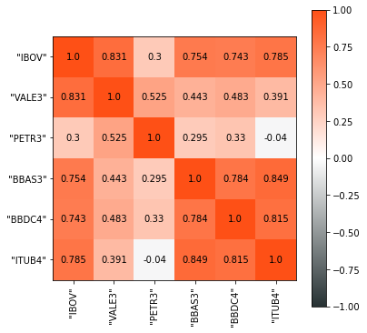

```python
import matplotlib.pyplot as plt
import seaborn as sns

vdf_allstocks_ibov = vDataFrameSQL("(select date, IBOV, VALE3, PETR3, BBAS3, BBDC4, ITUB4 from STOCK.STOCKQUOTESALL_IBOV) x")
vdf_allstocks_ibov.corr(method='pearson')
```

#### Análise da curva Elbow e o método best_k baseado no score de Elbow

```python
from verticapy.learn.model_selection import best_k

l_bestk = []
for vdf_stock in a_vdf_stocks:
    bestk = best_k(vdf_stock, X=['open','close'], n_cluster=(1,10), init='kmeanspp', elbow_score_stop=0.98)
    l_bestk.append(bestk)

display(l_bestk)
```

```
[9, 9, 9, 8, 8, 8]
```

**Within-Cluster SS**

**1**

0.0

**2**

0.718690420157962

**3**

0.9157691778940839

**4**

0.9474922329540704

**5**

0.9633176223084653

**6**

0.9725713126143214

**7**

0.9799057338507919

**8**

0.9847179359026511

**9**

0.9891008013969252

**Rows:** 1-9 | **Columns:** 2

**Within-Cluster SS**

**1**

0.0

**2**

0.6259733594801306

**3**

0.8402898386689839

**4**

0.919098427462745

**5**

0.9442306577143171

**6**

0.9597532766310851

**7**

0.9724311871526815

**8**

0.9765334727428557

**9**

0.9829432711645449

**Rows:** 1-9 | **Columns:** 2

**Within-Cluster SS**

**1**

0.0

**2**

0.6802681646987326

**3**

0.8437070992767705

**4**

0.9122412308319903

**5**

0.9404522746795768

**6**

0.9635608040518774

**7**

0.9711607748683121

**8**

0.9786402518429328

**9**

0.9813430446712372

**Rows:** 1-9 | **Columns:** 2

**Within-Cluster SS**

**1**

0.0

**2**

0.686365407428796

**3**

0.851110283911233

**4**

0.9299010723061598

**5**

0.956532405168685

**6**

0.9697818859461447

**7**

0.974124221456096

**8**

0.9827612318475045

**9**

0.986695321025063

**Rows:** 1-9 | **Columns:** 2

**Within-Cluster SS**

**1**

1.63946018497775e-16

**2**

0.7438994335368344

**3**

0.8811535954573438

**4**

0.9311904897234302

**5**

0.9586204569481177

**6**

0.9708137316408145

**7**

0.9769227055689977

**8**

0.9796260506021802

**9**

0.9846341958444196

**Rows:** 1-9 | **Columns:** 2

**Within-Cluster SS**

**1**

0.0

**2**

0.6659083148094659

**3**

0.882020817605683

**4**

0.9330208546023115

**5**

0.9603598352586807

**6**

0.9717443016841031

**7**

0.979894929785383

**8**

0.9845929958311407

**9**

0.9872632230255299

**Rows:** 1-9 | **Columns:** 2

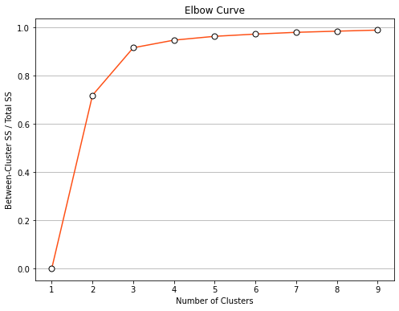

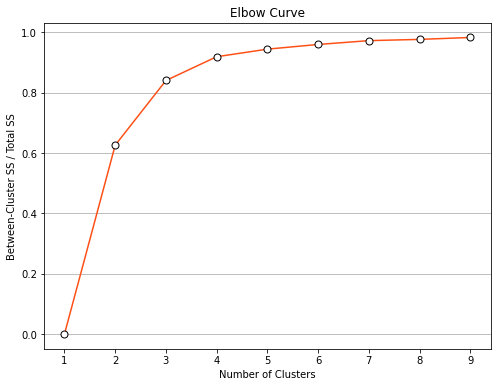

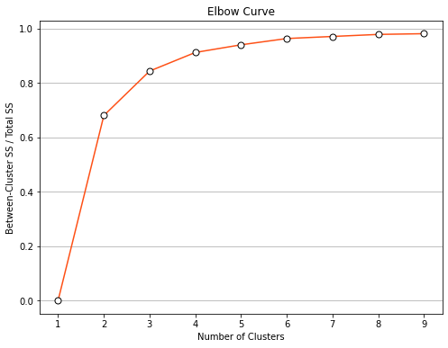

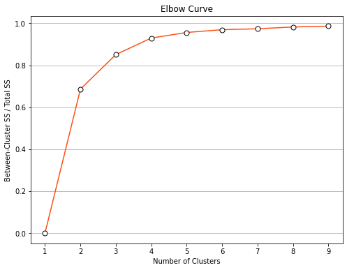

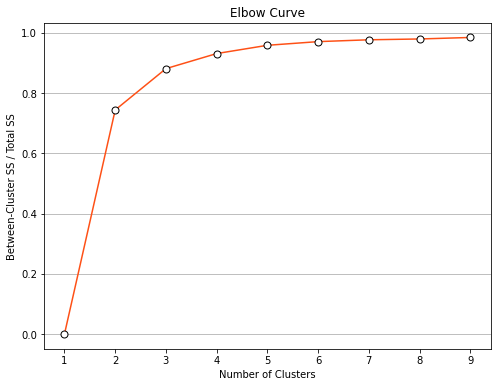

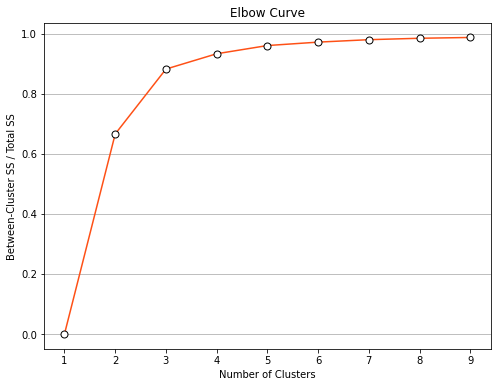

```python
from verticapy.learn.model_selection import elbow

for vdf_stock in a_vdf_stocks:
    celbow = elbow(vdf_stock, X=['open','close'], n_cluster=(1,10), init='kmeanspp')
    display(celbow)
```

## 3. Modelado de dados

Na fase de modelado de dados iremos:

- Criar um modelo de classificação não supervisionado "K-means" que calcula os centróides dos agrupamentos e repete o processo até que o centróide ótimo seja encontrado. Os pontos de dados são atribuídos aos agrupamentos de tal forma que a soma das distâncias quadradas entre os pontos de dados e o centroide seja a menor possível.
- Treinar o classificador com os dados dos preços de abertura e fechamento das ações
- Plotar os agrupamentos das observações
- Listar os centroides de cada agrupamento que identifica uma região de preços de suporte e resitência das ações

```
[                  open               close
 1     3976.87141385948    3971.77882589028
 2     80748.1592920354    80803.2949852507
 3     39915.5603448276    39938.6810344828
 4     100765.341772152    100788.744725738
 5     24364.8619329389     24392.325443787
 6     12704.8586193916    12698.8987320659
 7     65217.2538022814    65232.3935361217
 8     117361.607344633    117344.163841808
 9     53435.9111617312    53444.1799544419
 Rows: 1-9 | Columns: 2,
                   open               close
 1      5.7692287054409    5.77741144465291
 2     110.950721649485    110.771855670103
 3     78.2404516129032    78.1481290322581
```

[output cut: 48 more lines]

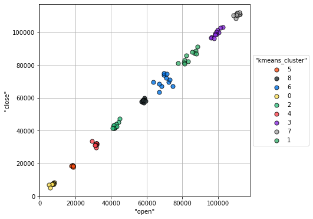

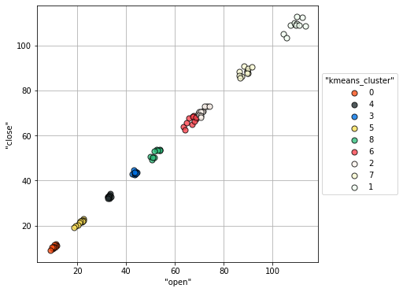

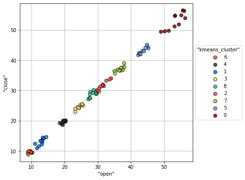

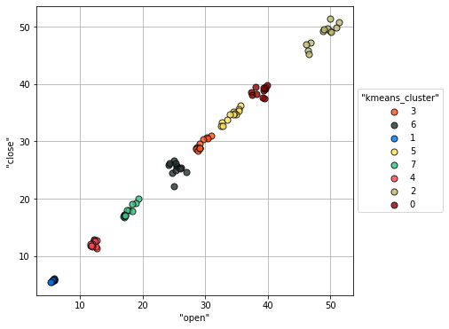

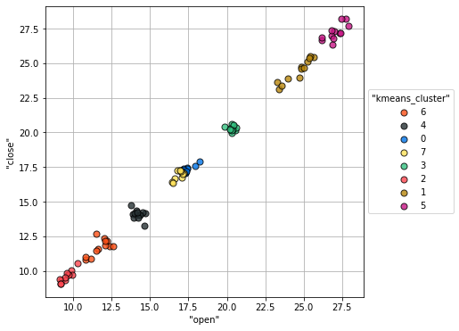

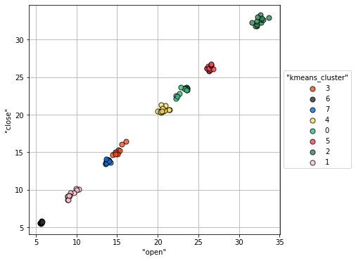

```python
from verticapy.learn.cluster import KMeans

l_cluster_centers = []
l_cluster_metrics = []

for idx, vdf_stock in enumerate(a_vdf_stocks):
    model = KMeans("KMeans_sm", n_cluster=l_bestk[idx], init='kmeanspp')
    model.fit(vdf_stock, ['open','close'])
    l_cluster_centers.append(model.cluster_centers_)
    l_cluster_metrics.append(model.metrics_)
    model.plot()

display(l_cluster_centers)
```

## 4. Avaliação do Modelo

Embora não existam métricas reais para avaliar modelos não supervisionados, as métricas usadas durante a computação podem nos ajudar a entender a qualidade do modelo.

Para um adequado modelo de agrupamento k-means a proporção entre a "Soma de quadrados da distança entre clusters" / "Soma total de quadrados" tem um valor próximo de 1. O desempenho do modelo parece muito bom, pós a proporção entre a "Soma de quadrados da distança entre clusters" / "Soma total de quadrados" é de 0.98.

```python
display(l_cluster_metrics)
```

```
[                                                      value
 Between-Cluster Sum of Squares             15792473000000.0
 Total Sum of Squares                       15966495000000.0
 Total Within-Cluster Sum of Squares          174022070000.0
 Between-Cluster SS / Total SS            0.9891008013969252
 converged                                              True
 Rows: 1-5 | Columns: 2,
                                                       value
 Between-Cluster Sum of Squares                    6193752.7
 Total Sum of Squares                              6301243.4
 Total Within-Cluster Sum of Squares               107490.69
 Between-Cluster SS / Total SS            0.9829413509086159
 converged                                              True
 Rows: 1-5 | Columns: 2,
                                                       value
 Between-Cluster Sum of Squares                    1362548.4
 Total Sum of Squares                              1388452.7
 Total Within-Cluster Sum of Squares                25904.26
 Between-Cluster SS / Total SS            0.9813430446712372
 converged                                              True
 Rows: 1-5 | Columns: 2,
                                                       value
 Between-Cluster Sum of Squares                    1694970.4
 Total Sum of Squares                              1724694.0
 Total Within-Cluster Sum of Squares               29723.591
 Between-Cluster SS / Total SS            0.9827658703514942
 converged                                              True
 Rows: 1-5 | Columns: 2,
                                                       value
 Between-Cluster Sum of Squares                    173908.13
 Total Sum of Squares                              177520.81
 Total Within-Cluster Sum of Squares               3612.6798
 Between-Cluster SS / Total SS            0.9796492591488288
 converged                                              True
 Rows: 1-5 | Columns: 2,
                                                       value
 Between-Cluster Sum of Squares                    934417.09
 Total Sum of Squares                              949005.39
 Total Within-Cluster Sum of Squares               14588.302
 Between-Cluster SS / Total SS            0.9846278006914164
 converged                                              True
 Rows: 1-5 | Columns: 2]
```

### Resultados da identificação de níveis de suporte e resistência nos preços das ações

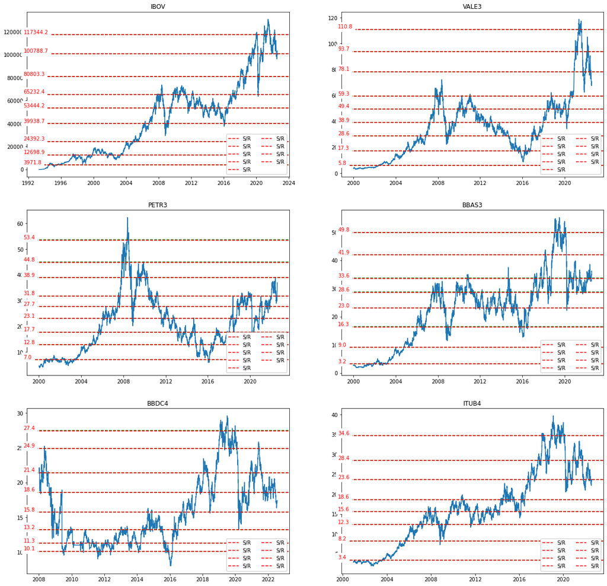

```python
import matplotlib.transforms as transforms

(nrows,ncols)=(3,2)
fig, axis = plt.subplots(nrows,ncols,figsize=(20, 20))
for i in range(nrows):
    for j in range(ncols):
        idx = i*ncols + j
        df_stock = a_vdf_stocks[idx].to_pandas()
        npClusters = l_cluster_centers[idx].to_numpy()
        axis[i][j].title.set_text(a_stock_symbols[idx])
        axis[i][j].plot(df_stock['date'], df_stock['close'])
        for arr_cluster in npClusters:
            axis[i][j].axhline( y=arr_cluster[0], color='green', ls='dashed')
            axis[i][j].axhline( y=arr_cluster[1], color='red', ls='dashed', label='S/R')
            axis[i][j].legend(frameon=True,framealpha=1,loc='lower right',ncol=2)
            trans = transforms.blended_transform_factory(axis[i][j].get_yticklabels()[0].get_transform(),axis[i][j].transData)
            axis[i][j].text(0,arr_cluster[0],"{:.1f}".format(arr_cluster[0]),color="red",transform=trans,ha="left",va="bottom",backgroundcolor="white",alpha=1)
            axis[i][j].text(0,arr_cluster[0],"{:.1f}".format(arr_cluster[1]),color="red",transform=trans,ha="left",va="bottom",backgroundcolor="white",alpha=1)
plt.figure()
plt.show()
```